# lab10_markdown

Bogumiła Okrojek

5/10/2023

MarkdownGuide - porady

pomiedzy ’’’ i ’’’ piszemy kod, przy czym po pierwszych w “{}” podajemy jezyk

mozna to stworzyc CTRL + ALT + I

include = FALSE oznacza, ze nie wyswietla sie okienko z kodem, ani z outputem

default - wyswietla okienko z kodem i pod nim okienko z outputem

mozna dodac do tekstu zmienna, ustalana w trakcie dzialania, fragment kodu, ktory wyswietli w tym miejscu wynik operacji robi sie to w ’’

ilosc # przed linijka nadaje jej styl naglowka - im wiecej # tym mniejszy naglowek do 6 (po # musi byc spacja; i przed i po naglowku w kodzie powinien byc pusta linijka)

do rozdzielenia paragrafow robi sie linie przerwy miedzy nimi

lamanie linii ’  
’znacznikiem

Pomiedzy * *jest kursywa*

Pomiedzy ** **jest pogrubiony tekst**

pomiedzy *** *jest kursywa i pogrubiony*

Pomiedzy tymi ciapkami przy ~ `napisany jest tekst techniczna czcionka`

pojedynczy ‘-’ to lacznik, aby napisac myslnik ‘–’ trzeba napisac 2 laczniki

Mozna formatowac linki - np. pogrubic **

## Tabele

-bez ’knitr’a

```r
mtcars[1:5,]
```

```
##                    mpg cyl disp  hp drat    wt  qsec vs am gear carb
## Mazda RX4         21.0   6  160 110 3.90 2.620 16.46  0  1    4    4
## Mazda RX4 Wag     21.0   6  160 110 3.90 2.875 17.02  0  1    4    4
## Datsun 710        22.8   4  108  93 3.85 2.320 18.61  1  1    4    1
## Hornet 4 Drive    21.4   6  258 110 3.08 3.215 19.44  1  0    3    1
## Hornet Sportabout 18.7   8  360 175 3.15 3.440 17.02  0  0    3    2
```

- z uzyciem ’knitr’a

```r
library(knitr)
kable(mtcars[1:5,])
```

|  | mpg | cyl | disp | hp | drat | wt | qsec | vs | am | gear | carb |
| --- | --- | --- | --- | --- | --- | --- | --- | --- | --- | --- | --- |
| Mazda RX4 | 21.0 | 6 | 160 | 110 | 3.90 | 2.620 | 16.46 | 0 | 1 | 4 | 4 |
| Mazda RX4 Wag | 21.0 | 6 | 160 | 110 | 3.90 | 2.875 | 17.02 | 0 | 1 | 4 | 4 |
| Datsun 710 | 22.8 | 4 | 108 | 93 | 3.85 | 2.320 | 18.61 | 1 | 1 | 4 | 1 |
| Hornet 4 Drive | 21.4 | 6 | 258 | 110 | 3.08 | 3.215 | 19.44 | 1 | 0 | 3 | 1 |
| Hornet Sportabout | 18.7 | 8 | 360 | 175 | 3.15 | 3.440 | 17.02 | 0 | 0 | 3 | 2 |

## Wykresy

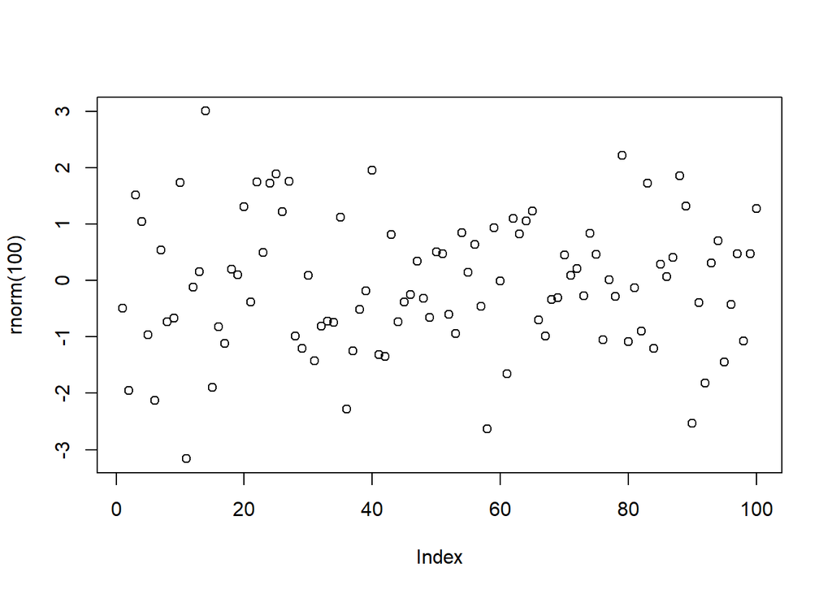

Rysunek 1

## Listy

Mozna zagniezdzac listy – im bardziej wewnetrzny element tym wiecej tabow przez nim w linijce

- lista
  - nienumerowana
- kolejne elementy od (`-`)
1. lista
2. numerowana
3. kolejne elementy od (numer elementu).

## Cytaty blokowe

> Cytat

## Obrazki

obrazek wstawia sie ! potem [] potem w () link do obrazka lub sciezke

OverLeaf - edytor Tex’a w przegladarce

## Uzycie TeX’a

w internecie sa opisy - sa: lietry greckie, znaki, kwantyfikatory itd

ulamek 1/2

$\frac{1}{2}$

jak najedzie sie na fragment kodu w tex to wyswietla sie podglad

calka

$\int_0^{\infty} x^2 \mathrm{d}x$

to mathrm jest po to, zeby to d nie bylo kursywa, niektorzy sie tego czepiaja

$\sum_{i=1^n} \frac{1}{i}$